# Newton Raphson for Optimization

February 3, 2020

## Poisson Model Example

Example A in Section 8.4 of Rice

The National Institute of Science and Technology did a study where they wanted to develop measurement standards for asbestos concentration. Asbestos dissolved in water was spread on a filter, and 3-mm diameter punches were taken from the filter and mounted on a transmission electron microscope. An operator counted the number of fibers in each of 23 grid squares. For the sake of illustration I am using just the first 5 observations here.

Let \(X_i\) be the number of fibers of asbestos found in square number \(i\).

Model: \(X_1, \ldots, X_n {\mathrel {\mathop {\sim}\limits _{}^{\rm iid}}\,}\text{Poisson}(\lambda)\)

## Log-likelihood and its derivatives

\[ \begin{align*} f(x_i | \lambda) &= e^{-\lambda} \frac{\lambda^{x_i}}{x_i!} \\ \ell(\lambda | x_1, \ldots, x_n) &= \, \cdots \, = -n \lambda + \log(\lambda) \sum_{i = 1}^n x_i - \sum_{i = 1}^n \log(x_i) \\ \frac{d}{d \lambda} \ell(\lambda | x_1, \ldots, x_n) &= \frac{1}{\lambda} \sum_{i = 1}^n x_i - n \\ \frac{d^2}{d \lambda^2} \ell(\lambda | x_1, \ldots, x_n) &= \frac{-1}{\lambda^2} \sum_{i = 1}^n x_i \end{align*} \]

We saw previously that \(\hat{\lambda}_{MLE} = \frac{1}{n} \sum_{i=1}^n x_i\)

In our example, \(\hat{\lambda}_{MLE} = 25.6\)

(This means we really don’t need numerical maximization methods for this example – I’m using this example so that we can check that the estimation worked by comparing to what we know to be the correct answer.)

## Log-likelihood function, MLE

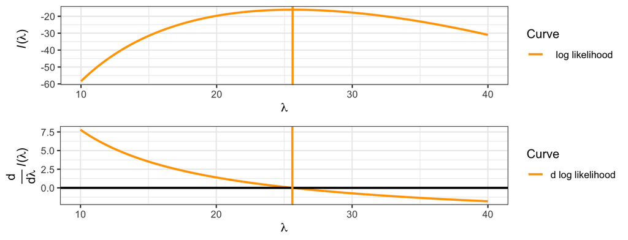

The vertical orange line is at the MLE:

- maximizes log-likelihood function
- at a root (0) of the first derivative of the log-likelihood function

…But what if we couldn’t solve for the MLE directly?

## Maximize Taylor Approx. to \(\ell(\lambda)\)

Pick a value \(\lambda_0\). The second-order Taylor Series approximation to \(\ell(\lambda | x_1, \ldots, x_n)\) around \(\lambda_0\) is

\[ \begin{align*} P_2(\lambda) &= \ell(\lambda_0 | x_1, \ldots, x_n) + \frac{d}{d\lambda} \ell(\lambda_0 | x_1, \ldots, x_n)(\lambda -\lambda_0) \\ &\qquad + \frac{1}{2} \frac{d^2}{d\lambda^2} \ell(\lambda_0 | x_1, \ldots, x_n)(\lambda -\lambda_0)^2 \\ \end{align*} \]

If \(\frac{d^2}{d\lambda^2} \ell(\lambda_0 | x_1, \ldots, x_n) < 0\), \(P_2\) is maximized when its first derivative is 0:

\(0 = \frac{d}{d\lambda}P_2(\lambda) = \frac{d}{d\lambda} \ell(\lambda_0 | x_1, \ldots, x_n) + \frac{d^2}{d\lambda^2} \ell(\lambda_0 | x_1, \ldots, x_n)(\lambda -\lambda_0)\) \(\Rightarrow \lambda = \lambda_0 - \frac{\frac{d}{d\lambda} \ell(\lambda_0 | x_1, \ldots, x_n)}{\frac{d^2}{d\lambda^2} \ell(\lambda_0 | x_1, \ldots, x_n)}\)

This will be our updated estimate, \(\lambda_1\)

Now repeat, but centering the Taylor Series approximation at \(\lambda_1\).

## Find Root of Taylor Approx. to \(\frac{d }{d \lambda} \ell(\lambda)\)

Pick a value \(\lambda_0\). The first-order Taylor Series approximation to \(\frac{d }{d \lambda} \ell(\lambda | x_1, \ldots, x_n)\) around \(\lambda_0\) is

\[ \begin{align*} P_1(\lambda) &= \frac{d}{d\lambda} L(\lambda_0 | x_1, \ldots, x_n) + \frac{d^2}{d\lambda^2} \ell(\lambda_0 | x_1, \ldots, x_n)(\lambda -\lambda_0) \\ \end{align*} \]

The root of \(P_1(\lambda)\) is at \(\lambda = \lambda_0 - \frac{\frac{d}{d\lambda} L(\lambda_0 | x_1, \ldots, x_n)}{\frac{d^2}{d\lambda^2} L(\lambda_0 | x_1, \ldots, x_n)}\)

This will be our updated estimate, \(\lambda_1\)

Now repeat, but centering the Taylor Series approximation at \(\lambda_1\).

## Pick \(\lambda_0\)

- Often the initial value of \(\lambda_0\) is selected by the method of moments
- For this example, I picked a number arbitrarily

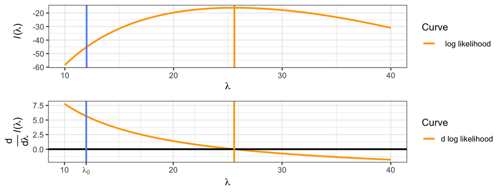

\[\lambda_0 = 12\]

## Approximate \(\ell(\lambda)\) around \(\lambda_0\), get \(\lambda_1\)

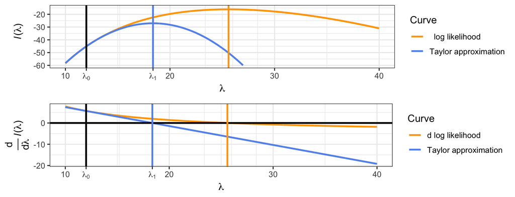

\[\lambda_0 = 12 \text{, } \lambda_1 = \lambda_0 - \frac{\frac{d}{d\lambda} L(\lambda_0 | x_1, \ldots, x_n)}{\frac{d^2}{d\lambda^2} L(\lambda_0 | x_1, \ldots, x_n)} = 18.375\]

## Approximate \(\ell(\lambda)\) around \(\lambda_1\), get \(\lambda_2\)

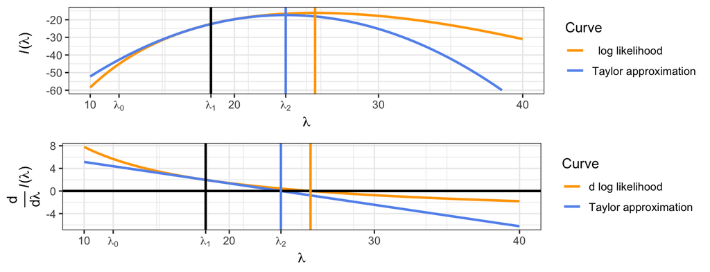

\[\lambda_0 = 12, \, \lambda_1 = 18.375,\] \[\lambda_2 = \lambda_1 - \frac{\frac{d}{d\lambda} L(\lambda_1 | x_1, \ldots, x_n)}{\frac{d^2}{d\lambda^2} L(\lambda_1 | x_1, \ldots, x_n)} = 23.561\]

## Approximate \(\ell(\lambda)\) around \(\lambda_2\), get \(\lambda_3\)

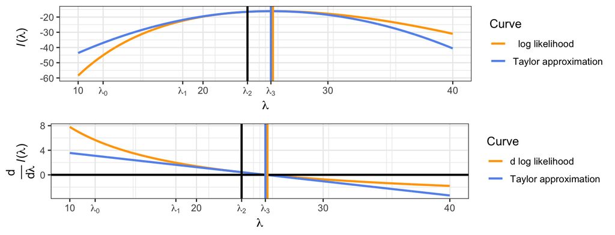

\[\lambda_0 = 12, \, \lambda_1 = 18.375, \lambda_2 = 23.561\] \[\lambda_3 = \lambda_2 - \frac{\frac{d}{d\lambda} L(\lambda_2 | x_1, \ldots, x_n)}{\frac{d^2}{d\lambda^2} L(\lambda_2 | x_1, \ldots, x_n)} = 25.438\]

## Approximate \(\ell(\lambda)\) around \(\lambda_3\), get \(\lambda_4\)

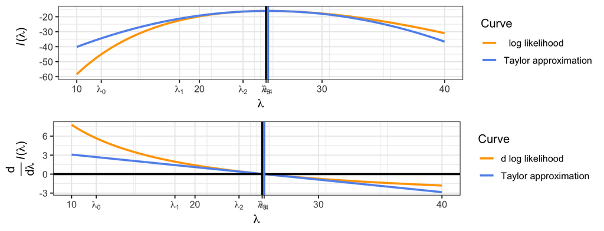

\[\lambda_0 = 12, \, \lambda_1 = 18.375, \lambda_2 = 23.561, \lambda_3 = 25.438\]

\[\lambda_4 = \lambda_3 - \frac{\frac{d}{d\lambda} L(\lambda_3 | x_1, \ldots, x_n)}{\frac{d^2}{d\lambda^2} L(\lambda_3 | x_1, \ldots, x_n)} = 25.599\]